# Selling SPY Weeklys: 2014 - 2018

Combining Risk Management Strategies

Pritam Dalal

February 4, 2019

In two previous analyses, we explored two different risk management strategies to employ while selling weekly SPY options:

1. threshold delta-hedging
2. unwinding positions when a certain loss-trigger is hit

When considered in isolation, the optimal threshold for delta-hedging is in the 35%-50% range. When daily delta-hedging, the optimal loss-trigger level for unwinding positions is around 125% of premium sold (max profits).

In this analysis, we combine these two risk management strategies to see if there is an optimal combination of delta-hedging threshold and loss-trigger percentage.

#### Sharpe Ratio Heat Map

The delta-hedge thresholds vary along the x-axis, increasing from left to right. The loss-trigger levels vary along the y-axis, increasing from bottom to top.

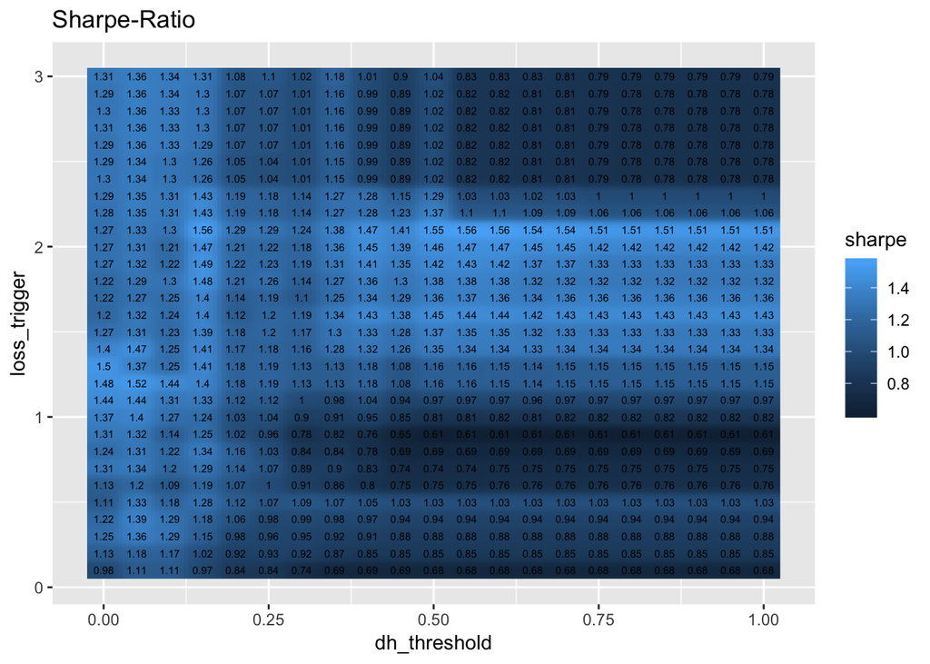

**Observations**

1. The left-most vertical strip of the heat map represents daily delta-hedging for various loss-trigger levels. The right-most vertical strip represents naked option selling for various loss-trigger levels.
2. The loss-trigger level has far less impact on daily delta-hedging than it does on naked option selling. This makes sense. Daily delta-hedging already provides a lot of risk management benefits, so overlaying an unwind strategy doesn’t add that much.
3. We have enough data that I buy the overall trends, but we don’t have enough data for me to believe some of the details. For example, for infrequent delta-hedging (threshold: 50%-100%) there is a big drop off in Sharpe-Ratio from a loss trigger of 2.1 to 2.2. The Sharpe decreases from about 1.53 to 1.08. I suspect this is just an artifact of the market path: by increasing the trigger from 2.1 to 2.2, we just happen expose ourselves to big losses for one particular expiration.
4. The overall trend that I see - most visible in the cases of infrequent hedging - is that both low loss-triggers and high loss-triggers lead to poor Sharpe-Ratios. This makes sense. If the loss-trigger is too low, you prematurely unwind trades the will end up being profitable. If the loss-trigger is too high, you expose yourself to large losses due to big moves in the underlying.

#### Conclusion

To my eye, for infrequent delta-hedging, say thresholds greater that 35%, there is a compelling case to be made for unwinding positions when losses reach about 150%-200% of max profit.

For delta-hedging that’s more frequent, it’s hard to say that unwinding positions results in that much performance improvement. However, it is still prudent to have such a policy, as it makes strong intuitive sense and it doesn’t seem to *hurt* performance. Under frequent delta-hedging, thresholds less than 35%, I would suggest a loss trigger between 100%-150% of max profit.

#### Appendix: Additional Heat Maps

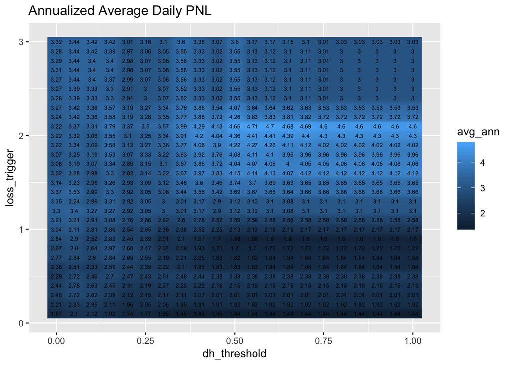

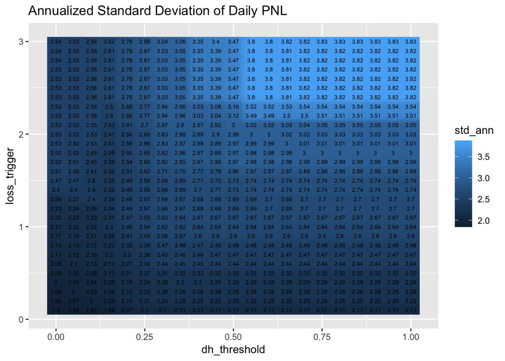